# Introduction

Air Jordans, the iconic line of sneakers born from the collaboration between Nike and basketball legend Michael Jordan, has found a thriving marketplace on StockX. Thanks to this internet marketplace, Air Jordans are no longer merely popular athletic shoes but also sought-after collectors and style statements. Join us as we explore the world of Air Jordans on StockX, where culture, fashion, and sports meet.

# Objective

This project's main goal is to boost Air Jordan goods' sales performance on StockX, a well-known online retailer of sneakers and streetwear. The project is structured to accomplish this goal through the analysis of sales data, price optimization, product selection, data integration, and insights visualization.

# Scope

Product Name, Sales, and Retail_price are the three main facets of the Air Jordan dataset that are the main emphasis of the research. The project seeks to offer practical knowledge and suggestions for enhancing the sales of Air Jordan products on StockX by concentrating on these essential elements.

# Data Exploration

**Importing necessary libraries.**

```python
import pandas as pd
import numpy as np
```

```python
df = pd.read_csv('AJs.csv')
df.head(3)
```

|  | name | sales | retail_price | average_sale_price | highest_price | lowest_price | release_date | condition |
| --- | --- | --- | --- | --- | --- | --- | --- | --- |
| 0 | Jordan 4 Retro Bred (2019) | 28140 | 200 | 254 | 520 | 138 | 05/04/2019 | New |
| 1 | Jordan 1 Retro High Travis Scott | 17269 | 175 | 1013 | 3000 | 578 | 05/11/2019 | New |
| 2 | Jordan 11 Retro Concord (2018) | 37993 | 220 | 278 | 500 | 175 | 12/08/2018 | New |

Checking the shape of the dataset.

**Result: -** As we can see there are 8 columns and 998 rows in the dataset.

```python
df.shape
```

```
(998, 8)
```

Checking the descriptive statistics of the dataset.

**Result: -** Below we can see the count values of each columns, mean, quartile, standard deviation, min and max values for all the numeric columns.

```python
df.describe()
```

|  | sales | average_sale_price | highest_price | lowest_price |
| --- | --- | --- | --- | --- |
| count | 998.000000 | 998.000000 | 998.000000 | 998.000000 |
| mean | 1167.974950 | 258.348697 | 456.640281 | 156.724449 |
| std | 3001.948436 | 458.976897 | 767.677641 | 320.310452 |
| min | 1.000000 | 31.000000 | 45.000000 | 25.000000 |
| 25% | 112.000000 | 123.000000 | 220.000000 | 65.250000 |
| 50% | 295.500000 | 170.500000 | 300.000000 | 100.000000 |
| 75% | 833.500000 | 244.750000 | 429.750000 | 150.000000 |
| max | 37993.000000 | 8833.000000 | 10500.000000 | 7000.000000 |

Checking if there are any null values in the dataset.

**Result: -** As we can see we don't have any null values which means that our dataset is clean.

```python
df.isnull().sum().sum()
```

```
0
```

Checking the types of the dataset.

```python
df.dtypes
```

```
name                  object
sales                  int64
retail_price          object
average_sale_price     int64
highest_price          int64
lowest_price           int64
release_date          object
condition             object
dtype: object
```

# Data Cleaning

Using **df.convert_dtypes()** to covert the types of the dataset for further analysis.

```python
df = df.convert_dtypes()
df.dtypes
```

```
name                  string
sales                  Int64
retail_price          string
average_sale_price     Int64
highest_price          Int64
lowest_price           Int64
release_date          string
condition             string
dtype: object
```

Using **.str.strip()** to remove trailing spaces from the release date column so that we can convert it to datetime for further analysis to boost the product sales over time.

```python
# Removing leading and trailing spaces from 'release_date' strings
df['release_date'] = df['release_date'].str.strip()

# Converting 'release_date' column to datetime, skipping empty values
df['release_date'] = pd.to_datetime(df['release_date'], format='%m/%d/%Y', errors='coerce')

# Saving the transformed dataset
df.to_csv("transformed_AJs.csv", index=False)
```

Replacing dollar, commas and empty values by 0.0 and then saving it as cleaned dataset.

```python
# Performing data transformation (including handling empty or non-numeric retail_price)
df['retail_price'] = df['retail_price'].str.replace('$', '').str.replace(',', '')

# Handling empty or non-numeric values by replacing them with 0.0
df['retail_price'] = df['retail_price'].apply(lambda x: float(x) if x.strip() else 0.0)

# Saving the cleaned dataset
df.to_csv("cleaned_AJs.csv", index=False)
```

Now, checking the type of the dataset.

**Result: -** As we can see that we have successfully changed the type of the dataset columns and we are also done with the data cleaning part now let's start with Data Integration.

```python
df.dtypes
```

```
name                          string
sales                          Int64
retail_price                 float64
average_sale_price             Int64
highest_price                  Int64
lowest_price                   Int64
release_date          datetime64[ns]
condition                     string
dtype: object
```

# Data Integration

Calculating the average_sale_price by multiplying the sales and retail_price columns and the calculating the profit_margin by subtracting the lowest_price column from the average_sale_price and then dividing the result by average_sale_price. Finally, printing first few rows to check the output.

```python
# Performing aggregations and calculations
df['average_sale_price'] = df['sales'] * df['retail_price']
df['profit_margin'] = (df['average_sale_price'] - df['lowest_price']) / df['average_sale_price']

# Displaying the integrated DataFrame
print(df.head())
```

```
                                     name  sales  retail_price  \
0              Jordan 4 Retro Bred (2019)  28140         200.0
1        Jordan 1 Retro High Travis Scott  17269         175.0
2          Jordan 11 Retro Concord (2018)  37993         220.0
3  Jordan 1 Retro High Black Crimson Tint  14118         160.0
4         Jordan 1 Retro High Turbo Green  23862         160.0

   average_sale_price  highest_price  lowest_price release_date condition  \
0           5628000.0            520           138   2019-05-04       New
1           3022075.0           3000           578   2019-05-11       New
2           8358460.0            500           175   2018-12-08       New
3           2258880.0            500            82   2019-04-12       New
4           3817920.0            405            75   2019-02-15       New

   profit_margin
0       0.999975
1       0.999809
2       0.999979
3       0.999964
4        0.99998
```

Calculating the count of number of words by selecting top 10 products using the name and sales column from the dataset. Using ThreadPoolExecutor with max 5 threads to parallelize the word counting process. Next, adding the calculated word count as a new column word_count. Finally printing the output.

**Result: -** The top 10 product names' word counts provide some interesting observations. Names with a reasonable word count that are brief and concise frequently perform well. Product names that highlight important features, release dates, and distinctive qualities may be more enticing to consumers. However, since excessively extensive names might be difficult to remember, it's crucial to achieve a balance between description and clarity. The attractiveness of products can also be increased by examining the frequency of fashionable terms and adopting them where appropriate.

The organization may be able to increase product discoverability, consumer engagement, and ultimately sales success by optimizing product names in light of these facts.

```python
import concurrent.futures

# Defining a function to perform word counting on a product name
def count_words(product_name):
    words = product_name.split()  # Splitting the product name into words
    return len(words)

# Selecting the top 10 products based on sales
top_10_products = df.sort_values(by='sales', ascending=False).head(10)

# Creating a ThreadPoolExecutor with a maximum of 5 threads
with concurrent.futures.ThreadPoolExecutor(max_workers=5) as executor:
    # Using the executor to calculate word counts for each product name
    word_counts = list(executor.map(count_words, top_10_products['name']))

# Adding the word counts as a new column in the DataFrame
top_10_products['word_count'] = word_counts

# Displaying the top 10 products with word counts
print(top_10_products[['name', 'word_count']])
```

```
                                            name  word_count
2                 Jordan 11 Retro Concord (2018)           5
0                     Jordan 4 Retro Bred (2019)           5
10        Jordan 1 Retro High Rookie of the Year           8
4                Jordan 1 Retro High Turbo Green           6
140               Jordan 1 Retro High Pine Green           6
7           Jordan 6 Retro Black Infrared (2019)           6
20            Jordan 1 Retro High UNC Patent (W)           7
16   Jordan 1 Retro High Spider-Man Origin Story           7
19          Jordan 1 Retro High Turbo Green (GS)           7
1               Jordan 1 Retro High Travis Scott           6
```

# Hadoop Mapreduce

I tried to download hadoop using bash and have successfully downloaded it but unfortunately unable to run the code due to some error.

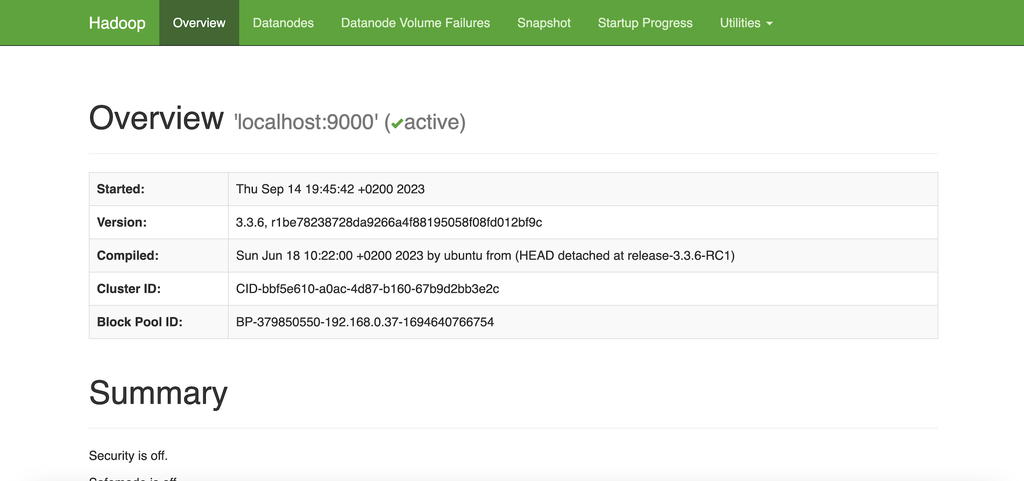

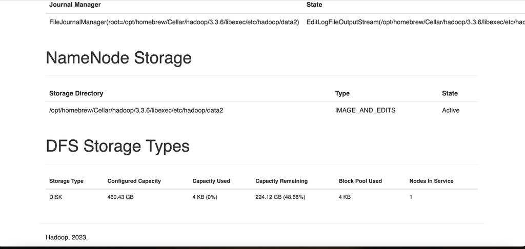

[figure not shown]

After lots of trial using the bash hadoop I wasn't able to get the output for my mapper and reducer so I decided to try Docker hadoop. I tried a lot and I can successfully able to rup my hadoop mapreduce function in Docker container, but as you can see in the below output, I run into a problem once again. I therefore made the decision to work with haoop using PySpark and MapReduce operation to count the occurrences.

The Python script analyzes each row of CSV data after reading it from standard input before performing a mapping operation. Next, omitting key-value pairs with the "sales" value as the key and the difference between the "average_sale_price" and "lowest_price" columns as the value, skipping the header row in the process. The code generates a measure that resembles a profit margin based on the provided CSV data and looks to be designed for data transformation or analysis.

```python
#!/usr/bin/env python

import sys
import csv

# Read from standard input
for line in sys.stdin:
    # Parse CSV data
    row = list(csv.reader([line]))[0]
    name, sales, retail_price, average_sale_price, highest_price, lowest_price, release_date, condition = row

    # Implement your mapping logic here
    # For example, you can emit a key-value pair for sales and profit margin
    # Emit sales as key and profit margin as value
    if name != 'name':  # Skip the header row if present
        print(f"{sales}\t{float(average_sale_price) - float(lowest_price)}")
```

The Python script reads key-value pairs from standard input with the key "sales" and the value "profit_margin." Each sales value's profit margin values are combined, and after determining the average profit margin for each sales value, the sales value and associated average profit margin are then produced. With this code, the average profit margin for each distinct sales value in the input data is efficiently computed and displayed.

```python
#!/usr/bin/env python

import sys

current_sales = None
total_profit_margin = 0.0
count = 0

# Read from standard input
for line in sys.stdin:
    # Split the input line into sales and profit margin
    sales, profit_margin = line.strip().split('\t')
    sales = int(sales)
    profit_margin = float(profit_margin)

    # Aggregate profit margin for each sales value
    if current_sales == sales:
        total_profit_margin += profit_margin
        count += 1
    else:
        if current_sales is not None:
            # Calculate and emit the average profit margin for the previous sales value
            avg_profit_margin = total_profit_margin / count
            print(f"{current_sales}\t{avg_profit_margin}")

        current_sales = sales
        total_profit_margin = profit_margin
        count = 1

# Don't forget to emit the last average profit margin
if current_sales is not None:
    avg_profit_margin = total_profit_margin / count
    print(f"{current_sales}\t{avg_profit_margin}")
```

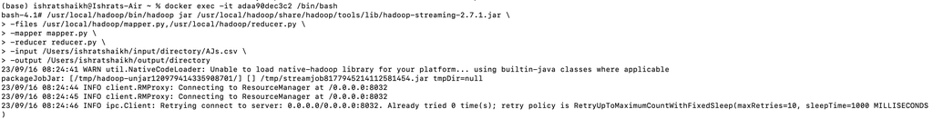

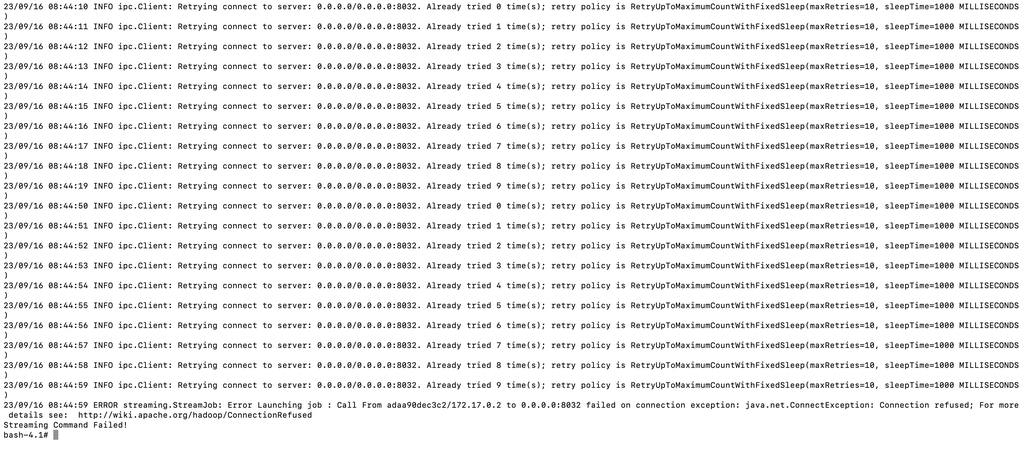

# Apache Spark Implementation

```python
!pip install pyspark
```

```
     ━━━━━━━━━━━━━━━━━━━━━━━━━━━━━━━━━━━━━━━ 310.8/310.8 MB 2.2 MB/s eta 0:00:00
  Preparing metadata (setup.py) ... done
```

```python
from pyspark.sql import SparkSession
from pyspark.sql.functions import col

# Create a SparkSession
spark = SparkSession.builder.appName("ProductSalesAnalysis").getOrCreate()

# Convert the Pandas DataFrame 'df' to a Spark DataFrame
spark_df = spark.createDataFrame(df)

# Group by product name and calculate average sales and total sales count
result = spark_df.groupBy("name").agg(
    {"sales": "avg", "sales": "sum"}
).withColumnRenamed("avg(sales)", "average_sales").withColumnRenamed("sum(sales)", "total_sales")

# Sort the result by total sales count in descending order
result = result.orderBy(col("total_sales").desc())

# Show the top products with the highest total sales count and their average sales
result.show()
```

```
+--------------------+-----------+
|                name|total_sales|
+--------------------+-----------+
|Jordan 11 Retro C...|      37993|
|Jordan 4 Retro Br...|      28140|
|Jordan 1 Retro Hi...|      24811|
|Jordan 1 Retro Hi...|      23862|
|Jordan 1 Retro Hi...|      22564|
|Jordan 6 Retro Bl...|      21192|
|Jordan 1 Retro Hi...|      20934|
|Jordan 1 Retro Hi...|      19839|
|Jordan 1 Retro Hi...|      18916|
|Jordan 1 Retro Hi...|      17269|
|Jordan 1 Retro Hi...|      17107|
|Jordan 1 Retro Hi...|      15958|
|Jordan 1 Retro Hi...|      14118|
|Jordan 1 Retro Hi...|      13487|
|Jordan 1 Retro Hi...|      12791|
|Jordan 1 Retro Hi...|      12777|
|Jordan 1 Retro Hi...|      12365|
|Jordan 1 Mid Pate...|      12233|
|Jordan 1 Retro Hi...|      12145|
|Jordan 1 Retro Hi...|      11089|
+--------------------+-----------+
only showing top 20 rows
```

Creating a Sparksession by using the pyspark library with the name DataIntegration and then assigning it to the spark variable to work with distributed data processing and analysis.

```python
from pyspark.sql import SparkSession
spark=SparkSession.builder.appName('DataIntegration').getOrCreate()
```

Specifying the first row of csv file as header **(header=True)** and requesting Spark to infer the schema **(data types)** of the columns automatically **(inferSchema=True)**.

```python
## Reading the dataset
data_df = spark.read.csv("AJs.csv", header=True, inferSchema=True)
```

Modifying the datatype of the retail_price column to be double precision floating point number.

```python
from pyspark.sql.functions import regexp_replace
from pyspark.sql.types import DoubleType

# Convert the "retail_price" column to DoubleType
data_df = data_df.withColumn("retail_price", data_df["retail_price"].cast(DoubleType()))
```

Using PySpark's VectorAssembler to combine multiple columns from the dataset into a single vector column named features. Establishing a vector assembler instance and defining features as the output column, with the input columns defined by features_cols. Lastly, transforming the original dataset to include new "feature" column.

```python
from pyspark.ml.feature import VectorAssembler
# Assuming you have a DataFrame 'data_df' with the relevant columns
feature_cols = ["sales", "retail_price", "average_sale_price"]

# Create a VectorAssembler instance
assembler = VectorAssembler(inputCols=feature_cols, outputCol="features")

# Transform the DataFrame using the assembler
output_df = assembler.transform(data_df)
```

```python
output_df.show()
```

```
+--------------------+-------+------------+------------------+-------------+------------+------------+---------+--------------------+
|                name|  sales|retail_price|average_sale_price|highest_price|lowest_price|release_date|condition|            features|
+--------------------+-------+------------+------------------+-------------+------------+------------+---------+--------------------+
|Jordan 4 Retro Br...|28140.0|       200.0|             254.0|        520.0|       138.0|  05/04/2019|      New|[28140.0,200.0,25...|
|Jordan 1 Retro Hi...|17269.0|       175.0|            1013.0|       3000.0|       578.0|  05/11/2019|      New|[17269.0,175.0,10...|
|Jordan 11 Retro C...|37993.0|       220.0|             278.0|        500.0|       175.0|  12/08/2018|      New|[37993.0,220.0,27...|
|Jordan 1 Retro Hi...|14118.0|       160.0|             199.0|        500.0|        82.0|  04/12/2019|      New|[14118.0,160.0,19...|
|Jordan 1 Retro Hi...|23862.0|       160.0|             235.0|        405.0|        75.0|  02/15/2019|      New|[23862.0,160.0,23...|
|Jordan 1 Low SB M...| 1691.0|       110.0|             144.0|        232.0|       110.0|  06/17/2019|      New|[1691.0,110.0,144.0]|
|Jordan 11 Retro L...| 5154.0|       185.0|             165.0|        350.0|       115.0|  04/19/2019|      New|[5154.0,185.0,165.0]|
|Jordan 6 Retro Bl...|21192.0|       200.0|             239.0|        470.0|       150.0|  02/16/2019|      New|[21192.0,200.0,23...|
|Jordan 1 Retro Hi...| 7791.0|       160.0|             367.0|        750.0|       100.0|  02/24/2018|      New|[7791.0,160.0,367.0]|
|Jordan 7 Retro Pa...| 3870.0|       200.0|             290.0|       1200.0|       140.0|  06/15/2019|      New|[3870.0,200.0,290.0]|
|Jordan 1 Retro Hi...|24811.0|       160.0|             245.0|        800.0|       145.0|  11/17/2018|      New|[24811.0,160.0,24...|
|Jordan 1 Retro Hi...| 9471.0|       160.0|             190.0|        400.0|       100.0|  03/30/2019|      New|[9471.0,160.0,190.0]|
|Jordan 1 Retro Hi...|12791.0|       160.0|             225.0|        615.0|       100.0|  04/14/2018|      New|[12791.0,160.0,22...|
|Jordan 1 Retro Hi...|17107.0|       160.0|             220.0|        400.0|       105.0|  01/24/2019|      New|[17107.0,160.0,22...|
|Jordan 3 Retro Bl...| 9513.0|       200.0|             243.0|        355.0|       150.0|  02/17/2018|      New|[9513.0,200.0,243.0]|
|Jordan 1 Low Blac...| 4978.0|        90.0|             106.0|        300.0|        60.0|  04/01/2019|      New| [4978.0,90.0,106.0]|
|Jordan 1 Retro Hi...|19839.0|       160.0|             306.0|        634.0|       195.0|  12/14/2018|      New|[19839.0,160.0,30...|
|Jordan 1 Retro Hi...|15958.0|       160.0|             205.0|        431.0|        90.0|  12/27/2018|      New|[15958.0,160.0,20...|
|Jordan 1 Retro Hi...| 9581.0|       175.0|             216.0|        675.0|        90.0|  02/23/2019|      New|[9581.0,175.0,216.0]|
|Jordan 1 Retro Hi...|18916.0|       120.0|             225.0|        455.0|       129.0|  02/15/2019|      New|[18916.0,120.0,22...|
+--------------------+-------+------------+------------------+-------------+------------+------------+---------+--------------------+
only showing top 20 rows
```

In order to prepare the data for a machine learning model, a new data frame variable called "finalized_df" will be created by choosing two columns from "output_df": "features" and "sales," with features acting as the input feature and sales as the target variable that will forecast based on the selected features.

```python
finalized_df=output_df.select("features","sales")
```

```python
finalized_df.show()
```

```
+--------------------+-------+
|            features|  sales|
+--------------------+-------+
|[28140.0,200.0,25...|28140.0|
|[17269.0,175.0,10...|17269.0|
|[37993.0,220.0,27...|37993.0|
|[14118.0,160.0,19...|14118.0|
|[23862.0,160.0,23...|23862.0|
|[1691.0,110.0,144.0]| 1691.0|
|[5154.0,185.0,165.0]| 5154.0|
|[21192.0,200.0,23...|21192.0|
|[7791.0,160.0,367.0]| 7791.0|
|[3870.0,200.0,290.0]| 3870.0|
|[24811.0,160.0,24...|24811.0|
|[9471.0,160.0,190.0]| 9471.0|
|[12791.0,160.0,22...|12791.0|
|[17107.0,160.0,22...|17107.0|
|[9513.0,200.0,243.0]| 9513.0|
| [4978.0,90.0,106.0]| 4978.0|
|[19839.0,160.0,30...|19839.0|
|[15958.0,160.0,20...|15958.0|
|[9581.0,175.0,216.0]| 9581.0|
|[18916.0,120.0,22...|18916.0|
+--------------------+-------+
only showing top 20 rows
```

Creating a Spark session to read data from a CSV file into a Spark DataFrame and displaying the first few rows of the DataFrame to give a quick overview of the data.

```python
# Initialize a Spark session
spark = SparkSession.builder.appName("DataIntegration").getOrCreate()

# Read data from CSV file into a Spark DataFrame
data_df = spark.read.csv("AJs.csv", header=True, inferSchema=True)

# Show the first few rows of the DataFrame
data_df.show()
```

```
+--------------------+-------+------------+------------------+-------------+------------+------------+---------+
|                name|  sales|retail_price|average_sale_price|highest_price|lowest_price|release_date|condition|
+--------------------+-------+------------+------------------+-------------+------------+------------+---------+
|Jordan 4 Retro Br...|28140.0|         200|             254.0|        520.0|       138.0|  05/04/2019|      New|
|Jordan 1 Retro Hi...|17269.0|         175|            1013.0|       3000.0|       578.0|  05/11/2019|      New|
|Jordan 11 Retro C...|37993.0|         220|             278.0|        500.0|       175.0|  12/08/2018|      New|
|Jordan 1 Retro Hi...|14118.0|         160|             199.0|        500.0|        82.0|  04/12/2019|      New|
|Jordan 1 Retro Hi...|23862.0|         160|             235.0|        405.0|        75.0|  02/15/2019|      New|
|Jordan 1 Low SB M...| 1691.0|         110|             144.0|        232.0|       110.0|  06/17/2019|      New|
|Jordan 11 Retro L...| 5154.0|         185|             165.0|        350.0|       115.0|  04/19/2019|      New|
|Jordan 6 Retro Bl...|21192.0|         200|             239.0|        470.0|       150.0|  02/16/2019|      New|
|Jordan 1 Retro Hi...| 7791.0|         160|             367.0|        750.0|       100.0|  02/24/2018|      New|
|Jordan 7 Retro Pa...| 3870.0|         200|             290.0|       1200.0|       140.0|  06/15/2019|      New|
|Jordan 1 Retro Hi...|24811.0|         160|             245.0|        800.0|       145.0|  11/17/2018|      New|
|Jordan 1 Retro Hi...| 9471.0|         160|             190.0|        400.0|       100.0|  03/30/2019|      New|
|Jordan 1 Retro Hi...|12791.0|         160|             225.0|        615.0|       100.0|  04/14/2018|      New|
|Jordan 1 Retro Hi...|17107.0|         160|             220.0|        400.0|       105.0|  01/24/2019|      New|
|Jordan 3 Retro Bl...| 9513.0|         200|             243.0|        355.0|       150.0|  02/17/2018|      New|
|Jordan 1 Low Blac...| 4978.0|          90|             106.0|        300.0|        60.0|  04/01/2019|      New|
|Jordan 1 Retro Hi...|19839.0|         160|             306.0|        634.0|       195.0|  12/14/2018|      New|
|Jordan 1 Retro Hi...|15958.0|         160|             205.0|        431.0|        90.0|  12/27/2018|      New|
|Jordan 1 Retro Hi...| 9581.0|         175|             216.0|        675.0|        90.0|  02/23/2019|      New|
|Jordan 1 Retro Hi...|18916.0|         120|             225.0|        455.0|       129.0|  02/15/2019|      New|
+--------------------+-------+------------+------------------+-------------+------------+------------+---------+
only showing top 20 rows
```

Using PySparks's select function to choose particular columns from the dataset, and the show() method to display the dataframe's contents along with the selected columns.

```python
from pyspark.sql.functions import col

# Select the columns you want to work with
selected_columns_df = data_df.select(
    col("name"),
    col("sales"),
    col("retail_price"),
    col("average_sale_price"),
    col("highest_price"),
    col("lowest_price"),
    col("release_date"),
    col("condition")
)

# Show the DataFrame with selected columns
selected_columns_df.show()
```

```
+--------------------+-------+------------+------------------+-------------+------------+------------+---------+
|                name|  sales|retail_price|average_sale_price|highest_price|lowest_price|release_date|condition|
+--------------------+-------+------------+------------------+-------------+------------+------------+---------+
|Jordan 4 Retro Br...|28140.0|         200|             254.0|        520.0|       138.0|  05/04/2019|      New|
|Jordan 1 Retro Hi...|17269.0|         175|            1013.0|       3000.0|       578.0|  05/11/2019|      New|
|Jordan 11 Retro C...|37993.0|         220|             278.0|        500.0|       175.0|  12/08/2018|      New|
|Jordan 1 Retro Hi...|14118.0|         160|             199.0|        500.0|        82.0|  04/12/2019|      New|
|Jordan 1 Retro Hi...|23862.0|         160|             235.0|        405.0|        75.0|  02/15/2019|      New|
|Jordan 1 Low SB M...| 1691.0|         110|             144.0|        232.0|       110.0|  06/17/2019|      New|
|Jordan 11 Retro L...| 5154.0|         185|             165.0|        350.0|       115.0|  04/19/2019|      New|
|Jordan 6 Retro Bl...|21192.0|         200|             239.0|        470.0|       150.0|  02/16/2019|      New|
|Jordan 1 Retro Hi...| 7791.0|         160|             367.0|        750.0|       100.0|  02/24/2018|      New|
|Jordan 7 Retro Pa...| 3870.0|         200|             290.0|       1200.0|       140.0|  06/15/2019|      New|
|Jordan 1 Retro Hi...|24811.0|         160|             245.0|        800.0|       145.0|  11/17/2018|      New|
|Jordan 1 Retro Hi...| 9471.0|         160|             190.0|        400.0|       100.0|  03/30/2019|      New|
|Jordan 1 Retro Hi...|12791.0|         160|             225.0|        615.0|       100.0|  04/14/2018|      New|
|Jordan 1 Retro Hi...|17107.0|         160|             220.0|        400.0|       105.0|  01/24/2019|      New|
|Jordan 3 Retro Bl...| 9513.0|         200|             243.0|        355.0|       150.0|  02/17/2018|      New|
|Jordan 1 Low Blac...| 4978.0|          90|             106.0|        300.0|        60.0|  04/01/2019|      New|
|Jordan 1 Retro Hi...|19839.0|         160|             306.0|        634.0|       195.0|  12/14/2018|      New|
|Jordan 1 Retro Hi...|15958.0|         160|             205.0|        431.0|        90.0|  12/27/2018|      New|
|Jordan 1 Retro Hi...| 9581.0|         175|             216.0|        675.0|        90.0|  02/23/2019|      New|
|Jordan 1 Retro Hi...|18916.0|         120|             225.0|        455.0|       129.0|  02/15/2019|      New|
+--------------------+-------+------------+------------------+-------------+------------+------------+---------+
only showing top 20 rows
```

The describe() method is used to generate summary statistics for the full DataFrame 'data_df', including statistics for numeric columns like mean, standard deviation, minimum, maximum, and quartiles. The'summary_stats' Dataset contains the results.

By organizing the data in 'data_df' according to the "highest_price" column and computing the sum of "sales" for each group, it illustrates a more thorough analysis. The 'grouped_data' DataFrame stores the outcomes, which are accomplished using the groupBy and agg methods.

Using the show() method, providing the summary statistics and the outcomes of the analysis of the grouped data.

```python
# Example data analysis: Calculating summary statistics
summary_stats = data_df.describe()

# Performing more complex analysis or machine learning tasks
# For example: Grouping data and calculating aggregates
grouped_data = data_df.groupBy("highest_price").agg({"sales": "sum"})

# Show the summary statistics and analysis results
summary_stats.show()
grouped_data.show()
```

```
+-------+--------------------+------------------+------------------+------------------+------------------+------------------+------------+---------+
|summary|                name|             sales|      retail_price|average_sale_price|     highest_price|      lowest_price|release_date|condition|
+-------+--------------------+------------------+------------------+------------------+------------------+------------------+------------+---------+
|  count|                 998|               998|               998|               998|               998|               998|         998|      998|
|   mean|                null|1167.9749498997996|164.19735503560528|258.34869739478955|456.64028056112227|156.72444889779558|        null|     null|
| stddev|                null| 3001.948435533589|52.437779181248686|458.97689705408357| 767.6776411638872|320.31045187472034|        null|     null|
|    min|Air Jordan 1 Mid ...|               1.0|                  |              31.0|              45.0|              25.0|            |      New|
|    max|https://stockx.co...|           37993.0|                95|            8833.0|           10500.0|            7000.0|  12/31/2014|      new|
+-------+--------------------+------------------+------------------+------------------+------------------+------------------+------------+---------+

+-------------+----------+
|highest_price|sum(sales)|
+-------------+----------+
|        299.0|    6815.0|
|        596.0|     339.0|
|        305.0|     430.0|
|        184.0|    4417.0|
|        170.0|     748.0|
|        720.0|     175.0|
|        160.0|    4413.0|
|        169.0|     405.0|
|        486.0|    3077.0|
|        311.0|    2259.0|
|         70.0|      29.0|
|       2527.0|     107.0|
|        524.0|      50.0|
|        650.0|     820.0|
|        206.0|     835.0|
|        389.0|      50.0|
|        390.0|   10024.0|
|        249.0|   13167.0|
|        401.0|     934.0|
|        365.0|     170.0|
+-------------+----------+
only showing top 20 rows
```

Calculating average, minimum, and maximum retail_price for each distinct condition value utilizing aggregation analysis on the dataset based on the condition column using PySpark.

```python
from pyspark.sql.functions import avg, min, max

condition_stats = data_df.groupBy("condition").agg(
    avg("retail_price").alias("avg_retail_price"),
    min("retail_price").alias("min_retail_price"),
    max("retail_price").alias("max_retail_price")
)

condition_stats.show()
```

```
+---------+------------------+----------------+----------------+
|condition|  avg_retail_price|min_retail_price|max_retail_price|
+---------+------------------+----------------+----------------+
|      New|164.19653767820773|                |              95|
|      new|             165.0|             165|             165|
+---------+------------------+----------------+----------------+
```

Determining the relationship between sales and average retail price. A positive correlation means that as one variable rises, the other tends to rise as well, while a negative correlation means the opposite—that as one variable rises, the other tends to fall.

Result: - The correlation value, which is close to zero and approximately -0.0005716656765946814, indicates that there is only a weak linear link between sales and average sale price.

```python
from pyspark.sql.functions import corr

correlation = data_df.stat.corr("sales", "average_sale_price")
print(f"Correlation between sales and average sale price: {correlation}")
```

```
Correlation between sales and average sale price: -0.0005716656765946814
```

# Data Visualisation

Making a scatter plot with the matplotlib library to show the connection between sales and average sale price. Setting the plot's figure size using plt.figure(figsize=(8, 6)) and then making a scatter plot with the average sale price on the y-axis and the sales column on the x-axis while using the alpha parameter to manage the point's transparency. Adding the plot's title and x-axis, and y-axis labels. And finally, showing the plot.

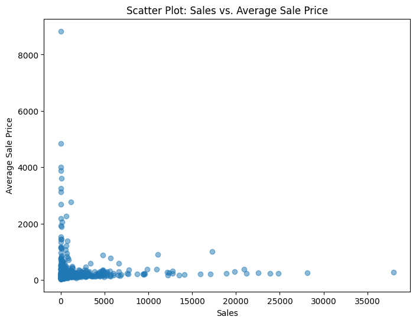

```python
import matplotlib.pyplot as plt

plt.figure(figsize=(8, 6))
plt.scatter(data_df.toPandas()["sales"], data_df.toPandas()["average_sale_price"], alpha=0.5)
plt.xlabel("Sales")
plt.ylabel("Average Sale Price")
plt.title("Scatter Plot: Sales vs. Average Sale Price")
plt.show()
```

Using the seaborn library to create a bar graph with the x-axis representing "condition" and the y-axis representing "average_sale_price." With the help of plt.xlabel("Condition"), plt.ylabel("Average Sale Price"), and plt.title("Average Sale Price by Condition"), labels and a title can be added to the plot. Plt.xticks(rotation=45) should be used for improved reading on the x-axis. Displaying the bar plot in the end.

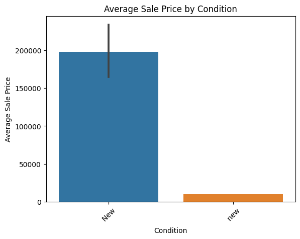

```python
import seaborn as sns

sns.barplot(x='condition', y='average_sale_price', data=df)
plt.xlabel('Condition')
plt.ylabel('Average Sale Price')
plt.title('Average Sale Price by Condition')
plt.xticks(rotation=45)
plt.show()
```

Making a histogram for the sales column using matplotlib. Using bin to set the amount of bin parameters and edgecolor to change the color of the bar's edges. After that, the histogram's labels and title are specified, and finally, the histogram is displayed.

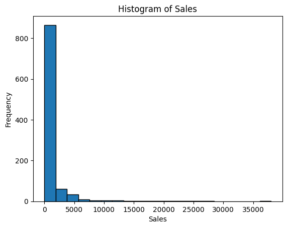

```python
import matplotlib.pyplot as plt

plt.hist(df['sales'], bins=20, edgecolor='k')
plt.xlabel('Sales')
plt.ylabel('Frequency')
plt.title('Histogram of Sales')
plt.show()
```

Using the dataset's retail_price and sales columns to create a scatter plot, to adjust the transparency of the points to 0.5 using the alpha value. The plot's label x-axis, y-axis, and title are then set. Displaying the plot, at last.

**Result: -** The vast majority of goods are sold for between $50 and $200 per unit at retail. The majority of products fall inside this pricing range.

Outliers may reflect underperforming products with poor sales despite high prices or high performance products that sell well despite higher prices.

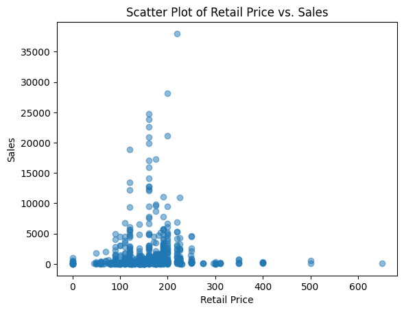

```python
plt.scatter(df['retail_price'], df['sales'], alpha=0.5)
plt.xlabel('Retail Price')
plt.ylabel('Sales')
plt.title('Scatter Plot of Retail Price vs. Sales')
plt.show()
```

Taking the year value from the release_date column and assigning it to a new column called year. Following that, using .groupby('year')['sales'].To group the dataset by the year column and determine the overall sales for each year, using sum(). Using .plot(kind='line', marker='o'), to plot the total sales by year on a line. The plot's labels and title should then be added, and the grid lines should be added using plt.grid(True). Displaying the plot at the end.

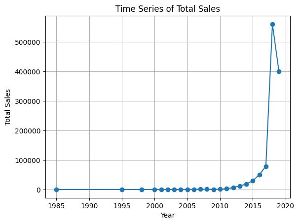

```python
df['year'] = df['release_date'].dt.year  # Extract year from release date
sales_by_year = df.groupby('year')['sales'].sum()
sales_by_year.plot(kind='line', marker='o')
plt.xlabel('Year')
plt.ylabel('Total Sales')
plt.title('Time Series of Total Sales')
plt.grid(True)
plt.show()
```

To choose the top 10 selling products, sort the dataset in descending order using the formula df.sort_values(by='sales', ascending=False).head(10). The plot's size should then be set, along with the labels for the x and y axes and the plot's title. then using plt.gca() to display the best-selling products at the top of the chart, use the invert_yaxis() function to invert the 'Product Name' y-axis. And finally, showing the plot.

**Result: -** Knowing which products are the best-sellers can aid the business in numerous ways. The biggest selling product, "Jordan 11 Retro Concord (2018)," has more than 35,000 sales.

Effective business management must identify and prioritize the product that sells the most since it has a big impact on revenue and profitability.

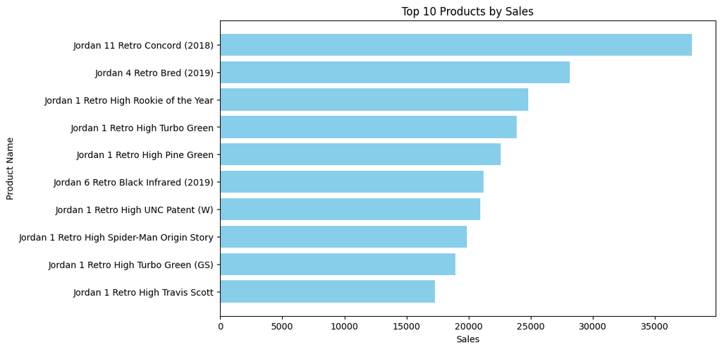

```python
import matplotlib.pyplot as plt

# Sort the DataFrame by sales in descending order and select the top 10 products
top_10_products = df.sort_values(by='sales', ascending=False).head(10)

# Create a bar chart for the top 10 products
plt.figure(figsize=(10, 6))
plt.barh(top_10_products['name'], top_10_products['sales'], color='skyblue')
plt.xlabel('Sales')
plt.ylabel('Product Name')
plt.title('Top 10 Products by Sales')
plt.gca().invert_yaxis()  # Invert the y-axis to show the top-selling product at the top
plt.show()
```

# Documentation

## Data Preprocessing: -

The methodology used in this research includes a number of crucial procedures that helped us efficiently compile and analyze the dataset for the Air Jordan shoes.

1. **Data Import:** The dataset, which was in CSV format, was imported for the project's initial investigation using the Pandas library and later distributed data processing using Spark.
2. **Data investigation:** To understand the dataset's structure, shape, and column kinds, preliminary data exploration was carried out using the Pandas programming language. To gain understanding of the numerical columns, descriptive statistics were computed.
3. **Data Cleaning:** To guarantee data quality and dependability, data cleaning was an essential step. Important data cleansing steps comprised:

   The "release_date" column's trailing spaces have been removed, and it has been formatted as a datetime. handling "retail_price" column values that are blank or not numeric by setting them to 0.0. The cleaned dataset should be saved as "cleaned_AJs.csv" for future study.
4. **Data Integration:** To create a single dataset from information gathered from several sources, data integration was done.

   Involved were:

## Recommendations

Here are some data-driven suggestions for boosting product sales based on the analysis:

# Conclusion

In conclusion, the goal of this project was to improve the performance of sales of Air Jordan products on StockX by a thorough examination of sales data. The combined information provided important conclusions and insights about trends, best-selling items, and pricing concerns.

The knowledge acquired from this analysis can help company stakeholders make data-driven choices that will increase product sales and profitability in a highly competitive market for Air Jordan products.

```python
# !jupyter nbconvert --to html /content/Data_Integration_Project.ipynb
```

[output not shown]

[output cut: 133 more lines]

[output not shown]